# Graphical EDA I: continous data

Team 1

29 December 2020

# Structure

**1. Examining Continuous Variables**

**2. Looking for Structure: Dependency Relationships and Associations**

**3. Investigating Multivariate Continuous Data**

# 1. Examining Continuous Variables

# 2. Looking for Structure: Dependency Relationships and Associations

### Exercise 1. Movie ratings

Figure 5.7

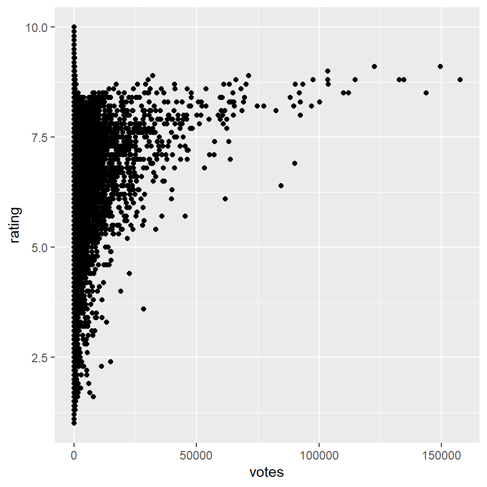

```r
library(ggplot2)
library(dplyr)
data(movies, package = "ggplot2movies")
 ggplot(movies, aes(votes, rating)) + geom_point() + ylim(1, 10)
```

1. Excluding all films with fewer than 100 votes:

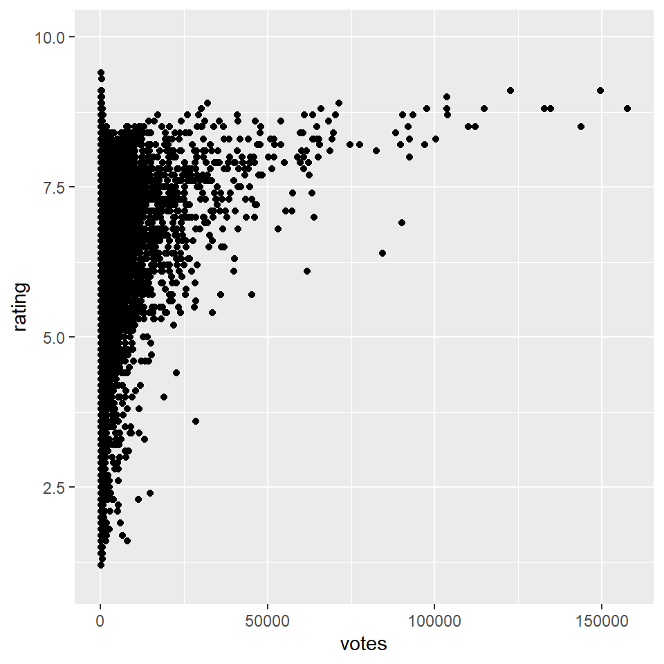

```r
library(ggplot2)
library(dplyr)

data(movies, package = "ggplot2movies")

filtered <- filter(movies, votes > 100)
ggplot(filtered, aes(votes, rating)) + geom_point() + ylim(1, 10)
```

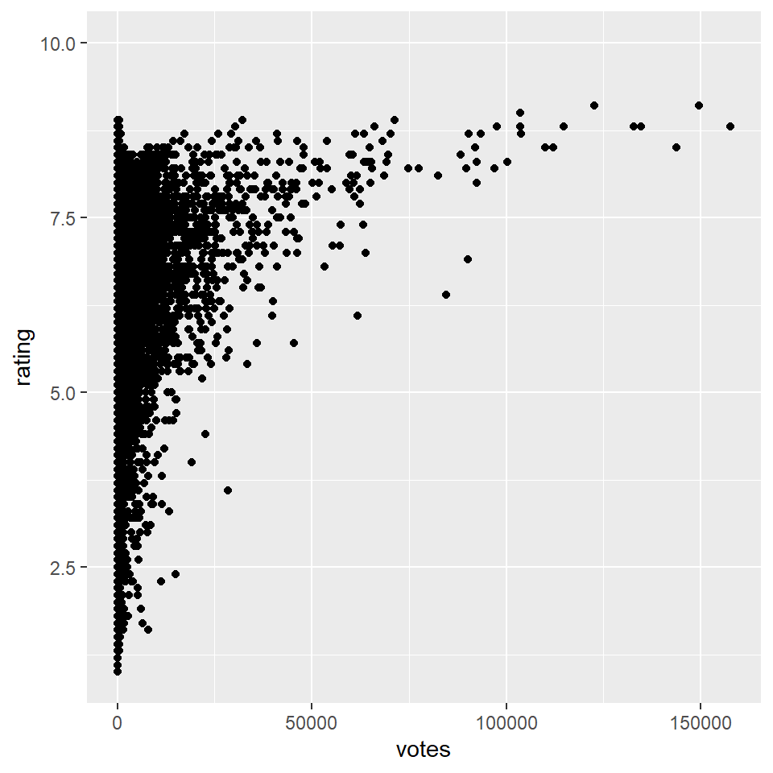

```r
library(ggplot2)
library(dplyr)

data(movies, package = "ggplot2movies")
filtered2 <- filter(movies, rating < 9 | votes>100000 )

ggplot(filtered2, aes(votes, rating)) + geom_point() + ylim(1, 10)
```

### Exercise 2. Meta analysis (**Olkin95** dataset)

1. Number of observations in each experimental group (n.e) against the corresponding number of observations in each control group (n.c):

```r
library(meta)
```

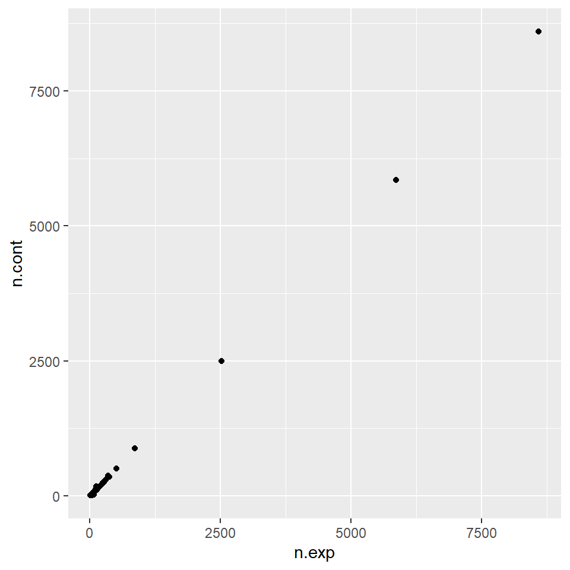

```r
data(Olkin1995)

ggplot(Olkin1995, aes(n.exp, n.cont)) + geom_point()
```

```r
# summary(metabin(ev.exp, n.exp, ev.cont, n.cont, data = Olkin1995))
#print(Olkin1995)
```

2. Restricting the scatterplot to only those with less than 100 patients in each group:

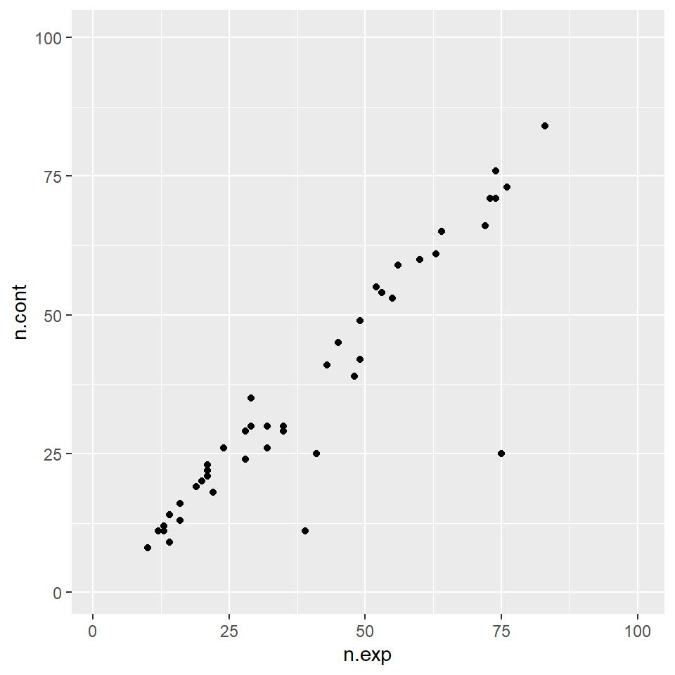

```r
library(meta)
data(Olkin1995)
ggplot(Olkin1995, aes(n.exp, n.cont)) + geom_point() + ylim(1, 100) + xlim(1,100)
```

We can observe easier now some outliers in the scatterplot, which were not visible before.

### Exercise 3. Zuni

1. Scatterplot of average revenue per pupil (Revenue) against the corresponding number of pupils (Mem):

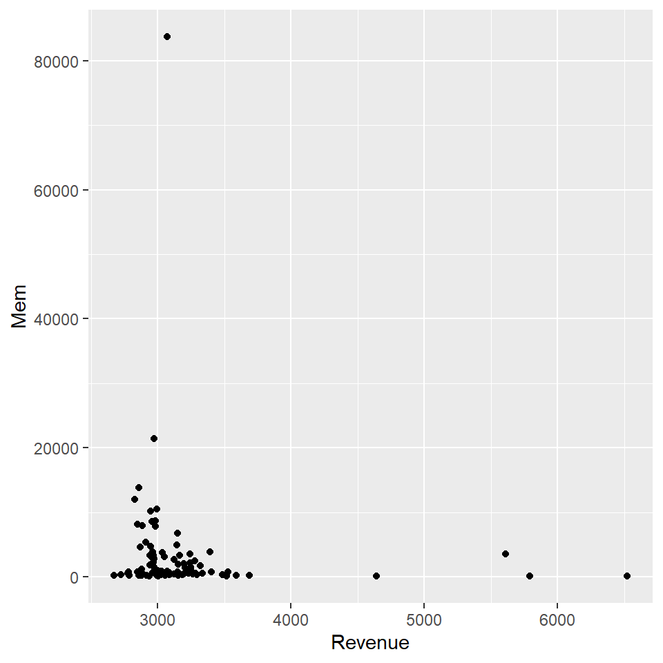

```r
library(lawstat)
data(zuni)
#print(zuni)
ggplot(zuni, aes(Revenue,Mem)) + geom_point()
```

2. Plotting against **log** of the number of pupils:

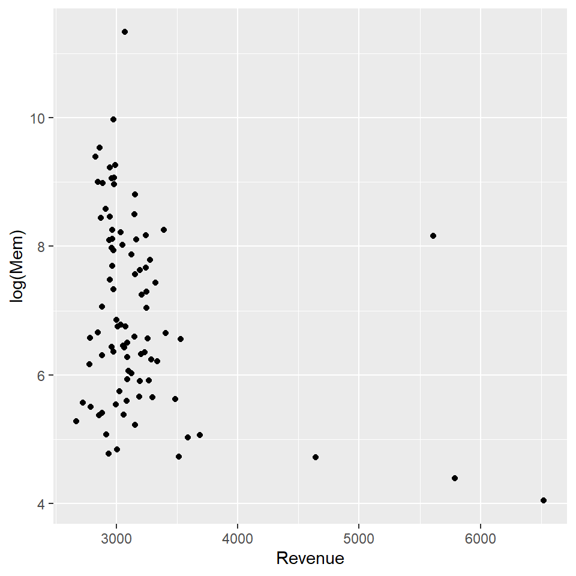

```r
library(lawstat)
data(zuni)
ggplot(zuni, aes(Revenue,log(Mem))) + geom_point()
```

Logging also revenue per pupil adds no other insight to the scatterplot, as shown below:

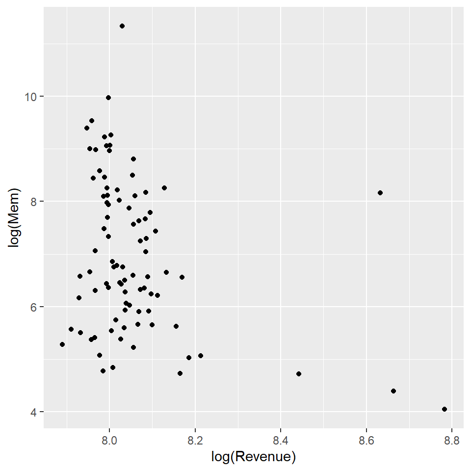

```r
library(lawstat)
data(zuni)
ggplot(zuni, aes(log(Revenue),log(Mem))) + geom_point()
```

### Exercise 4. Pearson heights

1. Scatterplot of the heights:

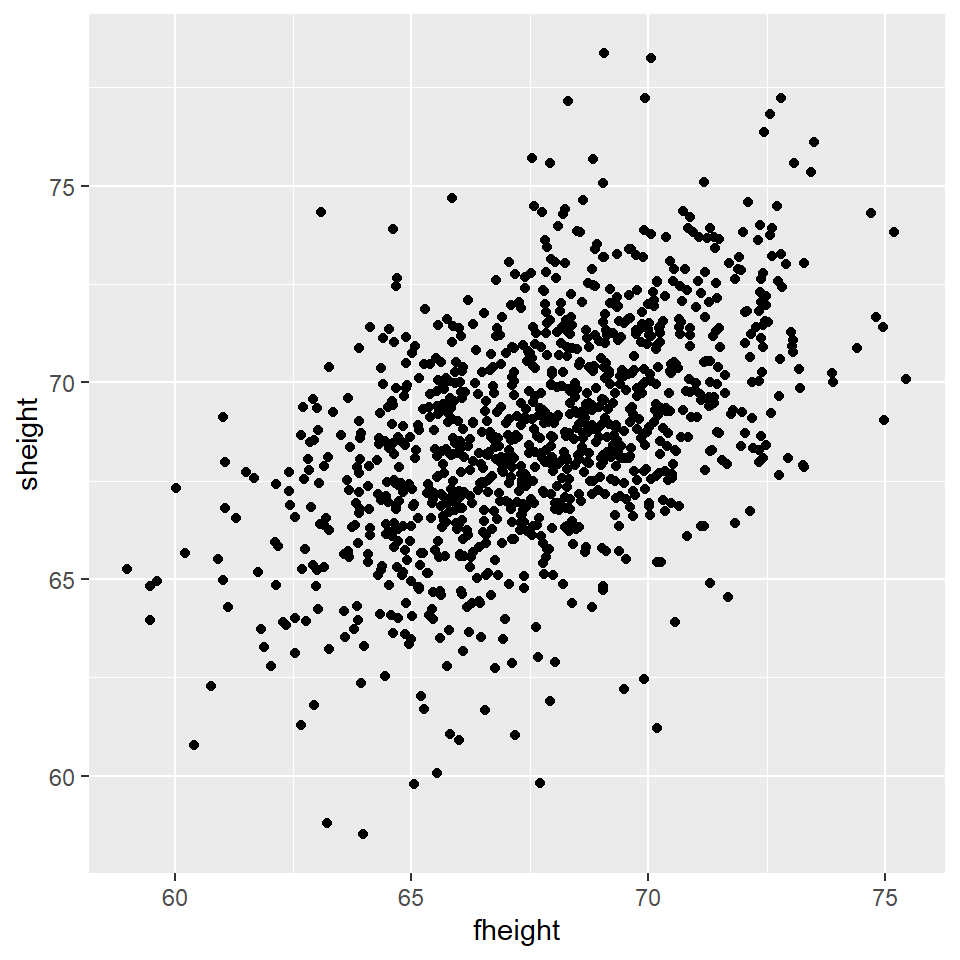

```r
data(father.son, package="UsingR")
ggplot(father.son, aes(fheight, sheight)) + geom_point()
```

2. Including both points and highest density regions:

```r
library(hdrcde)
```

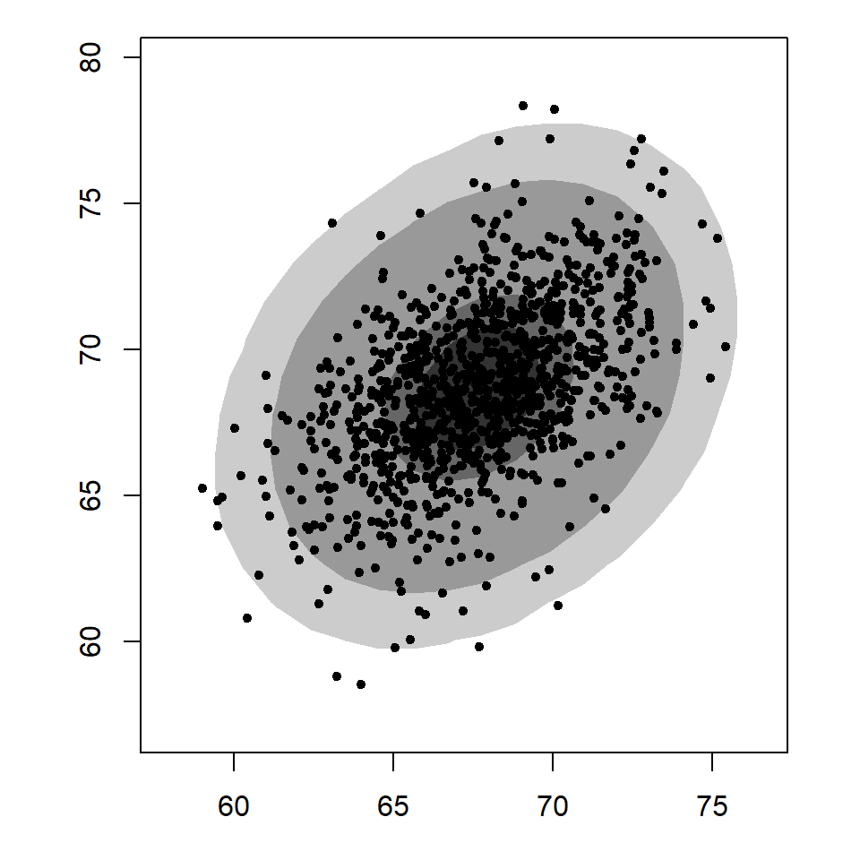

```r
data(father.son, package="UsingR")

par(mar=c(3.1, 4.1, 1.1, 2.1))
with(father.son,hdr.boxplot.2d(fheight, sheight, show.points=TRUE, prob=c(0.01,0.05,0.5,0.75)))
```

*Note:* **mar**= A numeric vector of length 4, which sets the margin sizes in the following order: bottom, left, top, and right. The default is c(5.1, 4.1, 4.1, 2.1).

3. Fitting a linear model to the data and a loess smooth:

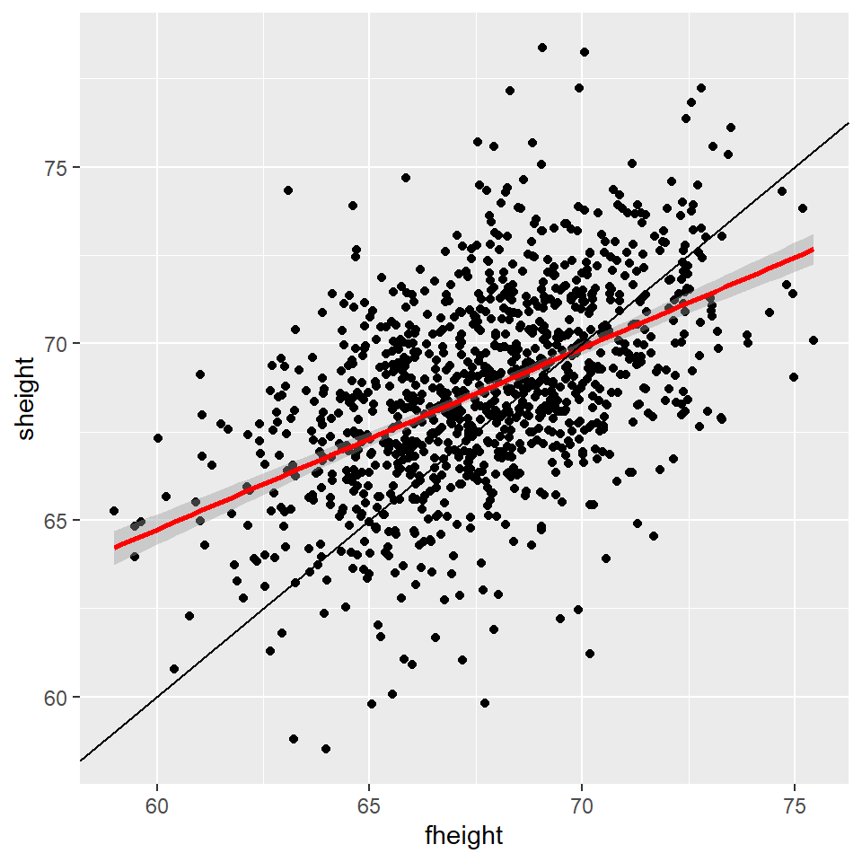

```r
data(father.son, package="UsingR")

ggplot(father.son, aes(fheight, sheight)) + geom_point() + geom_smooth(method="lm", colour="red") + geom_abline(slope=1, intercept=0)
```

A nonlinear model is not necessary, as the two curves are almost identical:

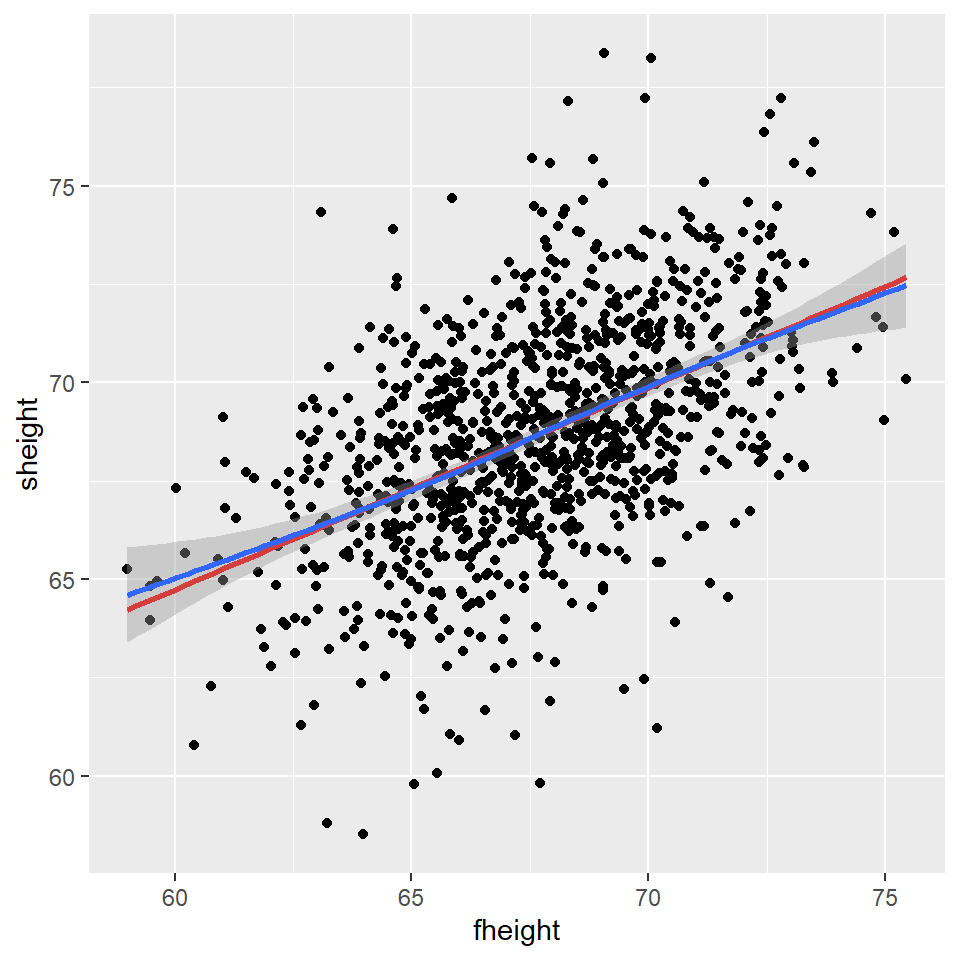

```r
data(father.son, package="UsingR")
ggplot(father.son, aes(fheight, sheight)) + geom_point() +
geom_smooth(method="lm", colour="red", se=FALSE) +
stat_smooth()
```

### Exercise 5. Bank discrimination

A subset of Roberts’ bank sex discrimination dataset from 1979 is available in the package **Sleuth2** under the name *case1202*.

1. Scatterplot matrix of the three variables: *Senior*, *Age* and *Exper*:

```r
library(GGally)
```

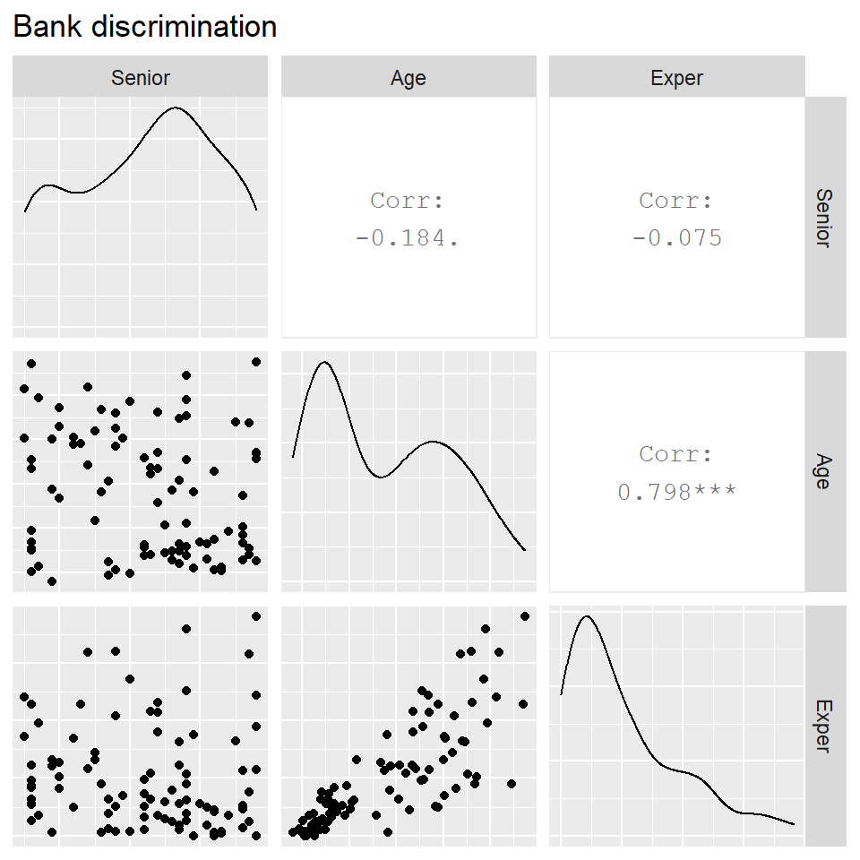

```r
data(case1202, package="Sleuth2")
#summary(case1202)
par(mar=c(1.1, 1.1, 1.1, 1.1))
#spm(select(case1202, c(4:5,7)), diagonal="histogram", smoother=FALSE, reg.line=FALSE) #groups=bank$Status)
ggpairs(case1202[,c(4:5, 7)], title="Bank discrimination", diag=list(continuous='density'), axisLabels='none')
```

### Exercise 6. Cars

Figure 5.8.

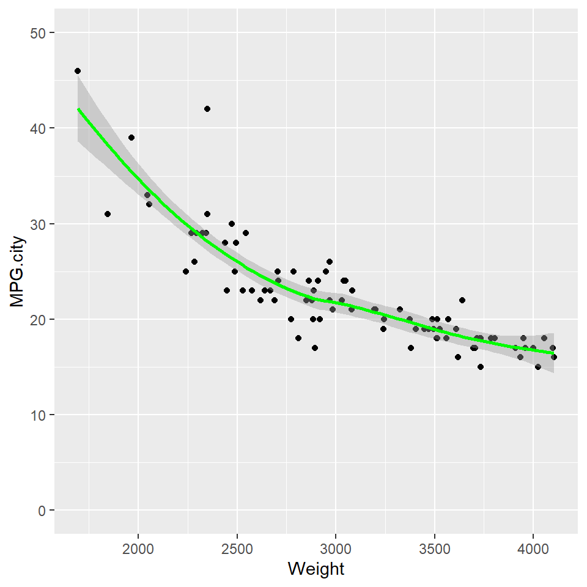

```r
data(Cars93, package="MASS")
#print(Cars93)
ggplot(Cars93, aes(Weight, MPG.city)) + geom_point() +
geom_smooth(colour="green") + ylim(0,50)
```

Note :fuel economy decreases with weight quite quickly initially and then more slowly.

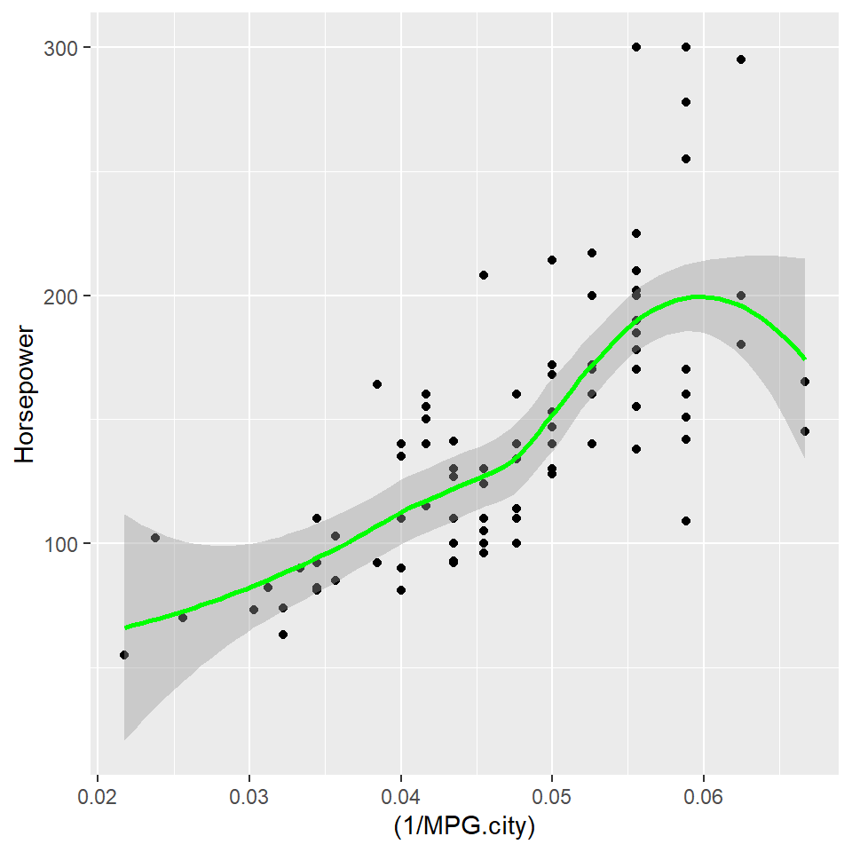

```r
data(Cars93, package="MASS")

ggplot(Cars93, aes((1/MPG.city), Horsepower)) + geom_point() + geom_smooth(colour="green")
```

```r
data(Cars93, package="MASS")
# filtered <- filter(Cars93, Horsepower <200 & MPG.city >20)
filtered <- filter(Cars93, Horsepower > 100)
#print(filtered)
```

### Exercise 7. Leaves

The *leafshape* dataset in the **DAAG** package includes three measurements on each leaf (length, width, petiole) and the logarithms of the three measurements.

1. Sploms for the two sets of three variables

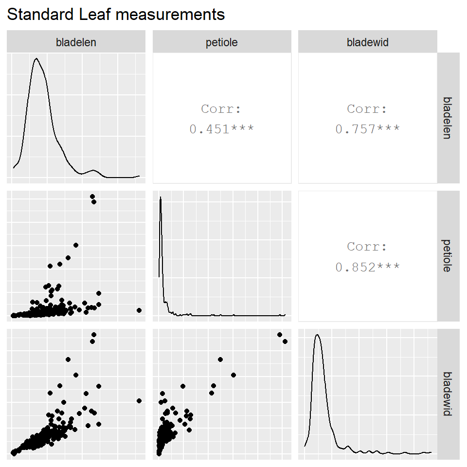

```r
library(GGally)
library(ggplot2)
data(leafshape, package="DAAG")
#summary(leafshape)
par(mar=c(1.1, 1.1, 1.1, 1.1))

ggpairs(leafshape[,c(1:3)], title="Standard Leaf measurements", diag=list(continuous='density'), axisLabels='none')
```

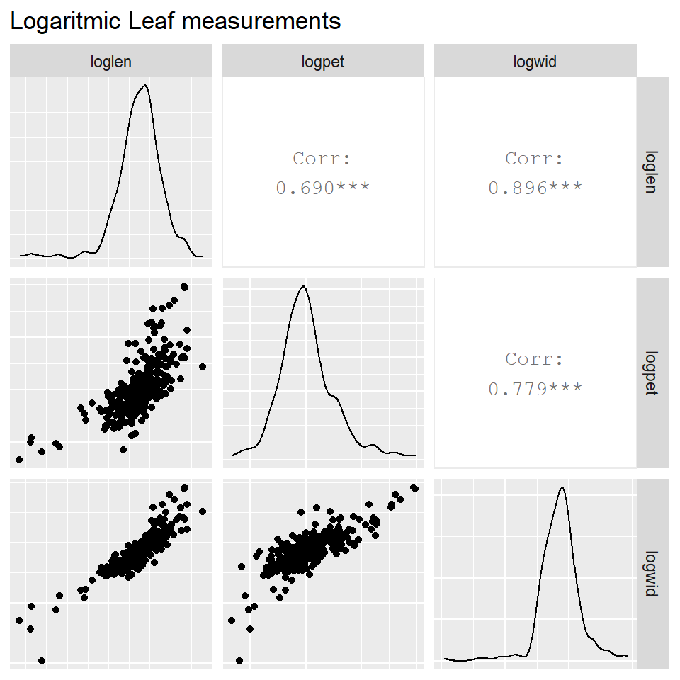

```r
#leafshape$arch <- unlist(leafshape$arch)

ggpairs(leafshape[,c(7:5)], title="Logaritmic Leaf measurements", diag=list(continuous='density'), axisLabels='none')
```

```r
#, mapping = ggplot2::aes(colour=leafshape[8]), lower = list(continuous = wrap("smooth", alpha = 0.3, size=0.1)))
```

# 3. Investigating Multivariate Continuous Data